# Multi-Class Classification Model for [Project Name] Using R version 06

## 3. Prepare Data

Some dataset may require additional preparation activities that will best exposes the structure of the problem and the relationships between the input attributes and the output variable. Some data-prep tasks might include:

- Cleaning data by removing duplicates, marking missing values and even imputing missing values.
- Feature selection where redundant features may be removed.
- Data transforms where attributes are scaled or redistributed in order to best expose the structure of the problem later to learning algorithms.

```r
email_notify(paste("Data Cleaning and Transformation has begun!",date()))
```

```
## [1] "Java-Object{org.apache.commons.mail.SimpleEmail@357246de}"
```

### 3.a) Data Cleaning

```r
# Not applicable for this iteration of the project.

# Mark missing values
#invalid <- 0
#entireDataset$some_col[entireDataset$some_col==invalid] <- NA

# Impute missing values
#entireDataset$some_col <- with(entireDataset, impute(some_col, mean))
```

### 3.b) Feature Selection

```r
# Not applicable for this iteration of the project.
```

### 3.c) Data Transforms

```r
# Not applicable for this iteration of the project.
```

### 3.d) Display the Final Dataset for Model-Building

```r
dim(xy_train)
```

```
## [1] 153  10
```

```r
sapply(xy_train, class)
```

```
##        RI        Na        Mg        Al        Si         K        Ca
## "numeric" "numeric" "numeric" "numeric" "numeric" "numeric" "numeric"
##        Ba        Fe targetVar
## "numeric" "numeric"  "factor"
```

```r
email_notify(paste("Data Cleaning and Transformation completed!",date()))
```

```
## [1] "Java-Object{org.apache.commons.mail.SimpleEmail@23223dd8}"
```

```r
proc.time()-startTimeScript
```

```
##    user  system elapsed
##   8.288   0.422  17.330
```

## 4. Model and Evaluate Algorithms

After the data-prep, we next work on finding a workable model by evaluating a subset of machine learning algorithms that are good at exploiting the structure of the training. The typical evaluation tasks include:

- Defining test options such as cross validation and the evaluation metric to use.
- Spot checking a suite of linear and nonlinear machine learning algorithms.
- Comparing the estimated accuracy of algorithms.

For this project, we will evaluate one linear, three non-linear, and three ensemble algorithms:

Linear Algorithm: Linear Discriminant Analysis

Non-Linear Algorithms: Decision Trees (CART), k-Nearest Neighbors, and Support Vector Machine

Ensemble Algorithms: Bagged CART, Random Forest, and Stochastic Gradient Boosting

The random number seed is reset before each run to ensure that the evaluation of each algorithm is performed using the same data splits. It ensures the results are directly comparable.

### 4.a) Generate models using linear algorithms

```r
# Linear Discriminant Analysis (Classification)
email_notify(paste("Linear Discriminant Analysis modeling has begun!",date()))
```

```
## [1] "Java-Object{org.apache.commons.mail.SimpleEmail@5a01ccaa}"
```

```r
startTimeModule <- proc.time()
set.seed(seedNum)
fit.lda <- train(targetVar~., data=xy_train, method="lda", metric=metricTarget, trControl=control)
print(fit.lda)
```

```
## Linear Discriminant Analysis
##
## 153 samples
##   9 predictor
##   6 classes: '1', '2', '3', '5', '6', '7'
##
## No pre-processing
## Resampling: Cross-Validated (10 fold, repeated 1 times)
## Summary of sample sizes: 139, 138, 138, 138, 136, 137, ...
## Resampling results:
##
##   Accuracy   Kappa
##   0.5859664  0.4221176
```

```r
proc.time()-startTimeModule
```

```
##    user  system elapsed
##   0.534   0.001   0.552
```

```r
email_notify(paste("Linear Discriminant Analysis modeling completed!",date()))
```

```
## [1] "Java-Object{org.apache.commons.mail.SimpleEmail@66d33a}"
```

### 4.b) Generate models using nonlinear algorithms

```r
# Decision Tree - CART (Regression/Classification)
email_notify(paste("Decision Tree modeling has begun!",date()))
```

```
## [1] "Java-Object{org.apache.commons.mail.SimpleEmail@c818063}"
```

```r
startTimeModule <- proc.time()
set.seed(seedNum)
fit.cart <- train(targetVar~., data=xy_train, method="rpart", metric=metricTarget, trControl=control)
print(fit.cart)
```

```
## CART
##
## 153 samples
##   9 predictor
##   6 classes: '1', '2', '3', '5', '6', '7'
##
## No pre-processing
## Resampling: Cross-Validated (10 fold, repeated 1 times)
## Summary of sample sizes: 139, 138, 138, 138, 136, 137, ...
## Resampling results across tuning parameters:
##
##   cp          Accuracy   Kappa
##   0.03367003  0.6465021  0.5161979
##   0.08080808  0.6005602  0.4294704
##   0.20202020  0.4369888  0.1487851
##
## Accuracy was used to select the optimal model using the largest value.
## The final value used for the model was cp = 0.03367003.
```

```r
proc.time()-startTimeModule
```

```
##    user  system elapsed
##   0.676   0.006   0.691
```

```r
email_notify(paste("Decision Tree modeling completed!",date()))
```

```
## [1] "Java-Object{org.apache.commons.mail.SimpleEmail@2c8d66b2}"
```

```r
# k-Nearest Neighbors (Regression/Classification)
email_notify(paste("k-Nearest Neighbors modeling has begun!",date()))
```

```
## [1] "Java-Object{org.apache.commons.mail.SimpleEmail@129a8472}"
```

```r
startTimeModule <- proc.time()
set.seed(seedNum)
fit.knn <- train(targetVar~., data=xy_train, method="knn", metric=metricTarget, trControl=control)
print(fit.knn)
```

```
## k-Nearest Neighbors
##
## 153 samples
##   9 predictor
##   6 classes: '1', '2', '3', '5', '6', '7'
##
## No pre-processing
## Resampling: Cross-Validated (10 fold, repeated 1 times)
## Summary of sample sizes: 139, 138, 138, 138, 136, 137, ...
## Resampling results across tuning parameters:
##
##   k  Accuracy   Kappa
##   5  0.6531583  0.5180926
##   7  0.6214426  0.4736815
##   9  0.6219678  0.4676250
##
## Accuracy was used to select the optimal model using the largest value.
## The final value used for the model was k = 5.
```

```r
proc.time()-startTimeModule
```

```
##    user  system elapsed
##   0.574   0.001   0.587
```

```r
email_notify(paste("k-Nearest Neighbors modeling completed!",date()))
```

```
## [1] "Java-Object{org.apache.commons.mail.SimpleEmail@2752f6e2}"
```

```r
# Support Vector Machine (Regression/Classification)
email_notify(paste("Support Vector Machine modeling has begun!",date()))
```

```
## [1] "Java-Object{org.apache.commons.mail.SimpleEmail@1d251891}"
```

```r
startTimeModule <- proc.time()
set.seed(seedNum)
fit.svm <- train(targetVar~., data=xy_train, method="svmRadial", metric=metricTarget, trControl=control)
print(fit.svm)
```

```
## Support Vector Machines with Radial Basis Function Kernel
##
## 153 samples
##   9 predictor
##   6 classes: '1', '2', '3', '5', '6', '7'
##
## No pre-processing
## Resampling: Cross-Validated (10 fold, repeated 1 times)
## Summary of sample sizes: 139, 138, 138, 138, 136, 137, ...
## Resampling results across tuning parameters:
##
##   C     Accuracy   Kappa
##   0.25  0.5882283  0.3942074
##   0.50  0.6411450  0.4774671
##   1.00  0.6803116  0.5425261
##
## Tuning parameter 'sigma' was held constant at a value of 0.2235569
## Accuracy was used to select the optimal model using the largest value.
## The final values used for the model were sigma = 0.2235569 and C = 1.
```

```r
proc.time()-startTimeModule
```

```
##    user  system elapsed
##   2.790   0.015   2.844
```

```r
email_notify(paste("Support Vector Machine modeling completed!",date()))
```

```
## [1] "Java-Object{org.apache.commons.mail.SimpleEmail@6e8dacdf}"
```

### 4.c) Generate models using ensemble algorithms

In this section, we will explore the use and tuning of ensemble algorithms to see whether we can improve the results.

```r
# Bagged CART (Regression/Classification)
email_notify(paste("Bagged CART modeling has begun!",date()))
```

```
## [1] "Java-Object{org.apache.commons.mail.SimpleEmail@7f63425a}"
```

```r
startTimeModule <- proc.time()
set.seed(seedNum)
fit.bagcart <- train(targetVar~., data=xy_train, method="treebag", metric=metricTarget, trControl=control)
print(fit.bagcart)
```

```
## Bagged CART
##
## 153 samples
##   9 predictor
##   6 classes: '1', '2', '3', '5', '6', '7'
##
## No pre-processing
## Resampling: Cross-Validated (10 fold, repeated 1 times)
## Summary of sample sizes: 139, 138, 138, 138, 136, 137, ...
## Resampling results:
##
##   Accuracy   Kappa
##   0.7634839  0.6794746
```

```r
proc.time()-startTimeModule
```

```
##    user  system elapsed
##   2.574   0.000   2.612
```

```r
email_notify(paste("Bagged CART modeling completed!",date()))
```

```
## [1] "Java-Object{org.apache.commons.mail.SimpleEmail@506e6d5e}"
```

```r
# Random Forest (Regression/Classification)
email_notify(paste("Random Forest modeling has begun!",date()))
```

```
## [1] "Java-Object{org.apache.commons.mail.SimpleEmail@60f82f98}"
```

```r
startTimeModule <- proc.time()
set.seed(seedNum)
fit.rf <- train(targetVar~., data=xy_train, method="rf", metric=metricTarget, trControl=control)
print(fit.rf)
```

```
## Random Forest
##
## 153 samples
##   9 predictor
##   6 classes: '1', '2', '3', '5', '6', '7'
##
## No pre-processing
## Resampling: Cross-Validated (10 fold, repeated 1 times)
## Summary of sample sizes: 139, 138, 138, 138, 136, 137, ...
## Resampling results across tuning parameters:
##
##   mtry  Accuracy   Kappa
##   2     0.7842682  0.6989294
##   5     0.7767577  0.6963403
##   9     0.7638410  0.6782535
##
## Accuracy was used to select the optimal model using the largest value.
## The final value used for the model was mtry = 2.
```

```r
proc.time()-startTimeModule
```

```
##    user  system elapsed
##   2.443   0.007   2.479
```

```r
email_notify(paste("Random Forest modeling completed!",date()))
```

```
## [1] "Java-Object{org.apache.commons.mail.SimpleEmail@6108b2d7}"
```

```r
# Stochastic Gradient Boosting (Regression/Classification)
email_notify(paste("Stochastic Gradient Boosting modeling has begun!",date()))
```

```
## [1] "Java-Object{org.apache.commons.mail.SimpleEmail@6aaa5eb0}"
```

```r
startTimeModule <- proc.time()
set.seed(seedNum)
fit.gbm <- train(targetVar~., data=xy_train, method="gbm", metric=metricTarget, trControl=control, verbose=F)
print(fit.gbm)
```

```
## Stochastic Gradient Boosting
##
## 153 samples
##   9 predictor
##   6 classes: '1', '2', '3', '5', '6', '7'
##
## No pre-processing
## Resampling: Cross-Validated (10 fold, repeated 1 times)
## Summary of sample sizes: 139, 138, 138, 138, 136, 137, ...
## Resampling results across tuning parameters:
##
##   interaction.depth  n.trees  Accuracy   Kappa
##   1                   50      0.6774335  0.5478767
##   1                  100      0.7108754  0.5962440
##   1                  150      0.7170168  0.6043157
##   2                   50      0.7171254  0.6061318
##   2                  100      0.7504587  0.6535315
##   2                  150      0.7633754  0.6721434
##   3                   50      0.7562920  0.6615674
##   3                  100      0.7638515  0.6715414
##   3                  150      0.7701015  0.6799155
##
## Tuning parameter 'shrinkage' was held constant at a value of 0.1
##
## Tuning parameter 'n.minobsinnode' was held constant at a value of 10
## Accuracy was used to select the optimal model using the largest value.
## The final values used for the model were n.trees = 150,
##  interaction.depth = 3, shrinkage = 0.1 and n.minobsinnode = 10.
```

```r
proc.time()-startTimeModule
```

```
##    user  system elapsed
##   2.447   0.014   2.489
```

```r
email_notify(paste("Stochastic Gradient Boosting modeling completed!",date()))
```

```
## [1] "Java-Object{org.apache.commons.mail.SimpleEmail@380fb434}"
```

### 4.d) Compare baseline algorithms

```r
results <- resamples(list(LDA=fit.lda, CART=fit.cart, kNN=fit.knn, SVM=fit.svm, BagCART=fit.bagcart, RF=fit.rf, GBM=fit.gbm))
summary(results)
```

```
##
## Call:
## summary.resamples(object = results)
##
## Models: LDA, CART, kNN, SVM, BagCART, RF, GBM
## Number of resamples: 10
##
## Accuracy
##              Min.   1st Qu.    Median      Mean   3rd Qu.      Max. NA's
## LDA     0.4000000 0.4833333 0.5798319 0.5859664 0.6656250 0.8125000    0
## CART    0.4000000 0.5470588 0.6666667 0.6465021 0.7410714 0.8125000    0
## kNN     0.5333333 0.6439076 0.6666667 0.6531583 0.6822917 0.7333333    0
## SVM     0.5333333 0.6000000 0.7000000 0.6803116 0.7458333 0.8125000    0
## BagCART 0.5333333 0.6833333 0.7750000 0.7634839 0.8487395 0.9375000    0
## RF      0.6000000 0.7411765 0.8062500 0.7842682 0.8642857 0.8750000    0
## GBM     0.5333333 0.7333333 0.7823529 0.7701015 0.8093750 1.0000000    0
##
## Kappa
##              Min.   1st Qu.    Median      Mean   3rd Qu.      Max. NA's
## LDA     0.1768293 0.2646549 0.3714734 0.4221176 0.5219156 0.7391304    0
## CART    0.1867470 0.4031325 0.5403171 0.5161979 0.6273959 0.7318436    0
## kNN     0.3558282 0.4931175 0.5297390 0.5180926 0.5612333 0.6428571    0
## SVM     0.3137255 0.4512195 0.5587474 0.5425261 0.6392652 0.7405405    0
## BagCART 0.3558282 0.5798319 0.6860093 0.6794746 0.7826899 0.9130435    0
## RF      0.4230769 0.6212963 0.7323701 0.6989294 0.8097746 0.8270270    0
## GBM     0.3269231 0.6085366 0.7053975 0.6799155 0.7405223 1.0000000    0
```

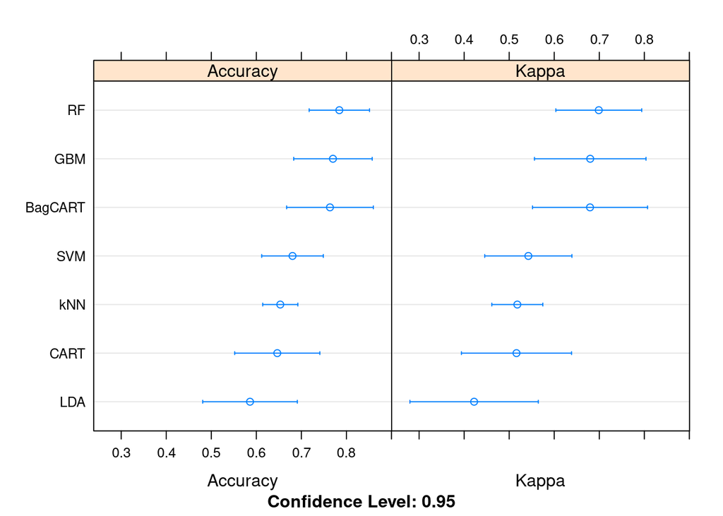

```r
dotplot(results)
```

```r
cat('The average accuracy from all models is:',
    mean(c(results$values$`LDA~Accuracy`,results$values$`CART~Accuracy`,results$values$`kNN~Accuracy`,results$values$`SVM~Accuracy`,results$values$`BagCART~Accuracy`,results$values$`RF~Accuracy`,results$values$`GBM~Accuracy`)))
```

```
## The average accuracy from all models is: 0.6976846
```

## 5. Improve Accuracy or Results

After we achieve a short list of machine learning algorithms with good level of accuracy, we can leverage ways to improve the accuracy of the models.

Using the three best-perfoming algorithms from the previous section, we will Search for a combination of parameters for each algorithm that yields the best results.